# HW 8: NHL stats

Shane Fuller

Fall 2019

# Preliminary notes for doing HW

1. All files should be knit and compiled using R Markdown. Knit early and often! I do not recommend waiting until the end of the HW to knit.
2. All questions should be answered completely, and, wherever applicable, code should be included.
3. If you work with a partner or group, please write the names of your teammates.
4. Copying and pasting of code is a violation of the Skidmore honor code

# Homework questions

We can access recent shot data here:

```r
library(RCurl); library(tidyverse)
gitURL<- "https://raw.githubusercontent.com/statsbylopez/StatsSports/master/Data/pbp_data_hockey.rds"
pbp_data <- readRDS(gzcon(url(gitURL)))
names(pbp_data)
```

```
##  [1] "season"         "game_id"        "game_date"      "session"
##  [5] "event_index"    "game_period"    "game_seconds"   "event_type"
##  [9] "home_team"      "away_team"      "home_skaters"   "away_skaters"
## [13] "home_score"     "away_score"     "event_detail"   "event_team"
## [17] "event_player_1" "event_player_2" "coords_x"       "coords_y"
## [21] "home_goalie"    "away_goalie"    "event_circle"   "event_distance"
## [25] "event_angle"    "shot_prob"
```

```r
dim(pbp_data)
```

```
## [1] 221380     26
```

## Question 1

Identify which NHL players have passes who have led to the highest expected goals. Note – the passing player is `event_player_2`. Hint: Connor McDavid should finish first.

```r
pbp_data %>%
  group_by(event_player_2) %>%
  summarise(pit_xg = sum(shot_prob)) %>%
  arrange(-pit_xg)
```

| event_player_2 | pit_xg |
| --- | --- |
| NA | 1.230842e+04 |
| CONNOR.MCDAVID | 1.427656e+01 |
| BLAKE.WHEELER | 1.408709e+01 |
| JAKUB.VORACEK | 1.406596e+01 |
| SEAN.COUTURIER | 1.396217e+01 |
| SIDNEY.CROSBY | 1.380664e+01 |
| JOSH.BAILEY | 1.377919e+01 |
| NIKITA.KUCHEROV | 1.289121e+01 |
| JOHNNY.GAUDREAU | 1.224599e+01 |
| LEON.DRAISAITL | 1.224543e+01 |

[output cut: 875 more lines]

*The players with passes who have led to the highest expected goals include Connor McDavid, Blake Wheeler, and Jakub Voracek.*

## Question 2

McDavid is credited with 14.3 expected goals off of his passes. In reality, he finished the 20182019 season with 75 assists. How come McDavid has so few expected assists in this data set? Think carefully about how NHL data is collected. If you aren’t sure, give a guess! But also explore the data to see if you pick anything up.

```r
pbp_data
```

| season | game_id | game_date | session | event_index | game_period | game_seconds | event_type | home_team | away_team | home_skaters | away_skaters | home_score | away_score | event_detail | event_team | event_player_1 | event_player_2 | coords_x | coords_y | home_goalie | away_goalie | event_circle | event_distance | event_angle | shot_prob |
| --- | --- | --- | --- | --- | --- | --- | --- | --- | --- | --- | --- | --- | --- | --- | --- | --- | --- | --- | --- | --- | --- | --- | --- | --- | --- |
| 20172018 | 2017020001 | 2017-10-04 | R | 11 | 1 | 38 | SHOT | WPG | TOR | 5 | 5 | 0 | 0 | Wrist | WPG | JOSH.MORRISSEY | NA | -37 | -27 | STEVE.MASON | FREDERIK.ANDERSEN | 2 | 58.6 | 27.4 | 0.006120646 |
| 20172018 | 2017020001 | 2017-10-04 | R | 15 | 1 | 49 | SHOT | WPG | TOR | 5 | 5 | 0 | 0 | Wrist | WPG | SHAWN.MATTHIAS | NA | -76 | 2 | STEVE.MASON | FREDERIK.ANDERSEN | 1 | 13.2 | 8.7 | 0.091498807 |
| 20172018 | 2017020001 | 2017-10-04 | R | 23 | 1 | 63 | SHOT | WPG | TOR | 5 | 5 | 0 | 0 | Backhand | WPG | BRYAN.LITTLE | NA | -74 | 11 | STEVE.MASON | FREDERIK.ANDERSEN | 1 | 18.6 | 36.3 | 0.053753931 |
| 20172018 | 2017020001 | 2017-10-04 | R | 31 | 1 | 75 | MISS | WPG | TOR | 5 | 5 | 0 | 0 | Wrist | WPG | TOBIAS.ENSTROM | NA | -34 | -18 | STEVE.MASON | FREDERIK.ANDERSEN | 2 | 57.9 | 18.1 | 0.014817776 |
| 20172018 | 2017020001 | 2017-10-04 | R | 36 | 1 | 106 | SHOT | WPG | TOR | 5 | 5 | 0 | 0 | Wrist | TOR | ERIC.FEHR | NA | 79 | -2 | STEVE.MASON | FREDERIK.ANDERSEN | 9 | 10.2 | 11.3 | 0.156606615 |
| 20172018 | 2017020001 | 2017-10-04 | R | 46 | 1 | 127 | MISS | WPG | TOR | 5 | 5 | 0 | 0 | Slap | TOR | RON.HAINSEY | NA | 36 | 27 | STEVE.MASON | FREDERIK.ANDERSEN | 8 | 59.5 | 27.0 | 0.012393842 |
| 20172018 | 2017020001 | 2017-10-04 | R | 51 | 1 | 138 | MISS | WPG | TOR | 5 | 5 | 0 | 0 | Wrist | TOR | NAZEM.KADRI | NA | 50 | 2 | STEVE.MASON | FREDERIK.ANDERSEN | 8 | 39.1 | 2.9 | 0.026932554 |
| 20172018 | 2017020001 | 2017-10-04 | R | 66 | 1 | 222 | SHOT | WPG | TOR | 5 | 4 | 0 | 0 | Snap | WPG | PATRIK.LAINE | NA | -45 | -20 | STEVE.MASON | FREDERIK.ANDERSEN | 2 | 48.3 | 24.4 | 0.041798327 |
| 20172018 | 2017020001 | 2017-10-04 | R | 67 | 1 | 230 | SHOT | WPG | TOR | 5 | 4 | 0 | 0 | Slap | WPG | DUSTIN.BYFUGLIEN | NA | -39 | -4 | STEVE.MASON | FREDERIK.ANDERSEN | 2 | 50.2 | 4.6 | 0.045723002 |
| 20172018 | 2017020001 | 2017-10-04 | R | 74 | 1 | 265 | MISS | WPG | TOR | 5 | 4 | 0 | 0 | Wrist | WPG | TYLER.MYERS | NA | -51 | -5 | STEVE.MASON | FREDERIK.ANDERSEN | 2 | 38.3 | 7.5 | 0.049228296 |

[output cut: 9990 more lines]

*Looking at the data set, a large majority of the entries for all shots taken have an N/A listed for event player 2. This is because it appears that a player is only listed for an assist if the shot was a successful goal. Therefore, this does not accurately represent the players true expected goals off passing, as shots that did not go in are not being factored. If the player who passed leading to the shot was listed for every row, then I believe that the expected goals off passes would be much closer to what was expected.*

## Question 3

A coach wants to know if players can consistently overperform the average finishing of an NHL players. Make a plot of each players’ goals above expectation in the 2018 season (+ or -) versus his goals above expectation in the 2019 data set. As a reminder, below is code from class which gets you started. You’ll need to make two new variables that correspond to goals above or below expectation in each season, and compare them graphically.

```r
season_2018 <- pbp_data %>%
  filter(season == 20172018) %>%
  group_by(event_player_1, season) %>%
  summarise(n_goals_18 = sum(event_type == "GOAL"),
            n_xGs_18 = sum(shot_prob),
            n_shots_18 = n()) %>%
  filter(n_shots_18 >= 100) %>%
  select(-season)

season_2019 <- pbp_data %>%
  filter(season == 20182019) %>%
  group_by(event_player_1, season) %>%
  summarise(n_goals_19 = sum(event_type == "GOAL"),
            n_xGs_19 = sum(shot_prob),
            n_shots_19 = n()) %>%
  filter(n_shots_19 >= 100) %>%
  select(-season)

season_combine <- season_2018 %>% inner_join(season_2019)
```

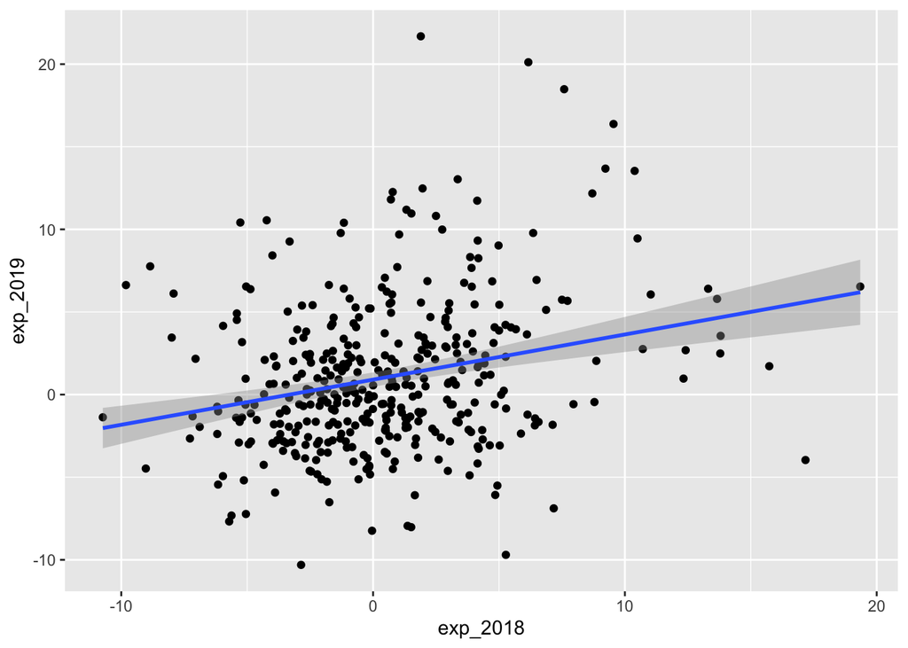

```r
season_combine <- season_combine %>%
  mutate(exp_2018 = n_goals_18-n_xGs_18,
         exp_2019 = n_goals_19-n_xGs_19)

ggplot(data = season_combine, aes(x = exp_2018, y = exp_2019)) + geom_point() + geom_smooth(method = "lm")
```

## Question 4

Is there any positive link between the two new variables you created for performance above expectation? Use a smoothed trend curve and/or linear regression to make your conclusion.

```r
fit_1 <- lm(exp_2019 ~ exp_2018, data = season_combine)
summary(fit_1)
```

```
##
## Call:
## lm(formula = exp_2019 ~ exp_2018, data = season_combine)
##
## Residuals:
##      Min       1Q   Median       3Q      Max
## -12.0451  -2.9031  -0.5434   1.9483  20.2623
##
## Coefficients:
##             Estimate Std. Error t value Pr(>|t|)
## (Intercept)  0.90565    0.22191   4.081 5.42e-05 ***
## exp_2018     0.27326    0.05188   5.268 2.27e-07 ***
## ---
## Signif. codes:  0 '***' 0.001 '**' 0.01 '*' 0.05 '.' 0.1 ' ' 1
##
## Residual standard error: 4.404 on 397 degrees of freedom
## Multiple R-squared:  0.06533,    Adjusted R-squared:  0.06297
## F-statistic: 27.75 on 1 and 397 DF,  p-value: 2.271e-07
```

*Based on the graph displayed above, there does appear to be positive link between expected goals between the 2018 season an the 2019 season, as it seems that if a player had more than expected in 2018, they were likely to have more than expected in the 2019 season. However, based on the linear regression model, the association does not appear to be very strong.*

## Question 5

Put your conclusion above into one to two sentences for a coach to understand.

*If a player on your team put in more shots than was expected in 2018, they are likely to put in more shots than expected in the next season as well. Similarly, if a player put in less shots than they were expected to in 2018, they are likely to put in less shots than expected in the next season as well.*

## Question 6

Identify the one player who was 10 goals better than expectation in 2018 and 10 goals better than expectation in 2019.

```r
season_combine %>%
  filter(exp_2018 >=10, exp_2019 >= 10)
```

| event_player_1 | n_goals_18 | n_xGs_18 | n_shots_18 | n_goals_19 | n_xGs_19 | n_shots_19 | exp_2018 | exp_2019 |
| --- | --- | --- | --- | --- | --- | --- | --- | --- |
| ALEX.OVECHKIN | 48 | 37.61269 | 522 | 51 | 37.46115 | 501 | 10.38731 | 13.53885 |

*Alex Ovechkin is the one player who was 10 goals better than expected in the 2018 and 2019 seasons.*